# Value of information for model validation

Amirhosein Farahmand Piruz

October 16, 2026

This guide is for researchers who validate clinical prediction models and want to know whether their validation sample is large enough to trust its conclusion. A validation sample is finite, so the net benefit of a model is uncertain, and the strategy that looks best (a model, treating everyone, or treating no one) may not be the best in the population. The value-of-information (VoI) functions of voipred.dev measure how much that uncertainty matters for the decision of which strategy to use, following Sadatsafavi et al. (2023, 2025) for EVPI and EVSI and Wynants et al. (2018) and Cruz and Korthauer (2025) for the probabilities that a model is useful or the best. They all take a result of `nb_val()` (see the net benefit guide, `voipred_nb_guide.Rmd`), with one model or several:

[output not shown]

Each result (and the P(useful) and P(best) in a result of `evpi()`) has `print()`, `summary()`, `as.data.frame()` and `plot()`, and EVPI and EVSI can also be drawn below the decision curve. Every function works for binary, survival and competing-risks outcomes and any number of models. When models are compared, give them to one call of `nb_val()`, as a list, and pass that result to the VoI functions; this guide does so throughout, and its last section shows that results computed separately can be used too. The help pages give the full details: `?evpi` (with P(useful) and P(best)), `?evsi`, `?summary.voipred_voi` and the `plot()` methods (`?plot.voipred_evpi`, …).

## Installation

voipred.dev is installed from GitHub. plotly (interactive plots) and patchwork (the panel below a static decision curve) are optional; partykit and coin are only used for the censoring tree in the EVPI section. voipred.dev has compiled (C++) code, so installing it needs a C++ compiler: Rtools on Windows, the Xcode command line tools on macOS (`xcode-select --install`); Linux has one already.

```r
options(repos = c(CRAN = "https://cloud.r-project.org"),
        install.packages.compile.from.source = "never")
lib <- Sys.getenv("R_LIBS_USER")
dir.create(lib, recursive = TRUE, showWarnings = FALSE)
.libPaths(c(lib, .libPaths()))

pkgs <- c(remotes = "0", plotly = "0", patchwork = "0", partykit = "0", coin = "0",
          prodlim = "0", insight = "0", Rcpp = "0", ggplot2 = "3.4.0",
          riskRegression = "2026.3.11")
missing_or_old <- function(p)
  !requireNamespace(p, quietly = TRUE) || utils::packageVersion(p) < pkgs[[p]]
new <- names(pkgs)[vapply(names(pkgs), missing_or_old, logical(1))]
if (length(new)) install.packages(new, lib = lib)

remotes::install_github("amirfarahmand0/voipred_dev", force = TRUE,   # voipred.dev
                        upgrade = "never", lib = lib)
```

Every package this guide uses is checked and loaded here, so that a missing one is reported at the start rather than halfway through (plotly and patchwork are only needed for the plots with panels and the interactive plots):

```r
pkgs <- c("voipred.dev", "survival", "riskRegression", "prodlim", "partykit",
          "coin", "plotly", "patchwork")
missing <- pkgs[!vapply(pkgs, requireNamespace, logical(1), quietly = TRUE)]
if (length(missing))
  stop("Install these packages first (see the code above): ",
       paste(missing, collapse = ", "))
library(voipred.dev)
library(survival)
```

# Setup: the net benefit

**Binary outcome.** GUSTO-I was an international randomized trial of four thrombolytic strategies in 40,830 patients with acute myocardial infarction (GUSTO investigators, 1993); voipred.dev ships its data as `gusto`. The outcome is death within 30 days (`day30`), about 7% of patients. We fit two logistic models on a random development sample of 5000 patients: a “full” model (age, Killip class, systolic blood pressure, pulse, previous infarction, infarct location and sex) and a model with age only. For illustration, we validate them on a small random sample of only 500 other patients, the size of the case study of Sadatsafavi et al. (2023), so that the uncertainty is visible; with thousands of validation patients it would be small. Both models are given to one call of `nb_val()`:

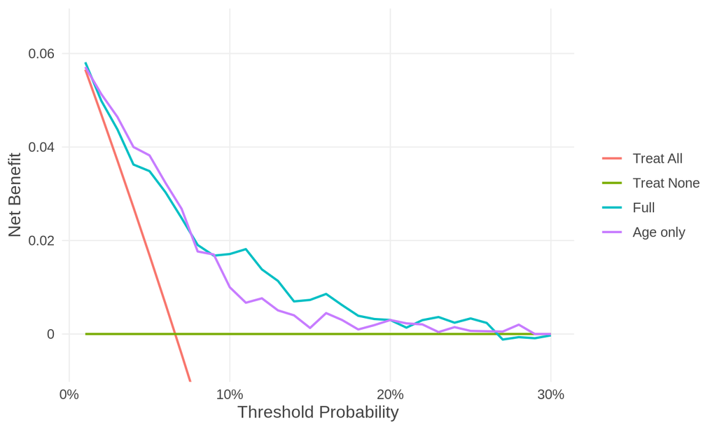

```r
set.seed(1)
i   <- sample(nrow(gusto))
df_dev_binary <- gusto[i[1:5000], ]
df_val_binary <- gusto[i[5001:5500], ]
fit_full <- glm(day30 ~ age + Killip + sysbp + pulse + pmi + miloc + sex,
                family = binomial, data = df_dev_binary)
fit_age  <- glm(day30 ~ age, family = binomial, data = df_dev_binary)
df_val_binary$p_full <- predict(fit_full, newdata = df_val_binary, type = "response")
df_val_binary$p_age  <- predict(fit_age, newdata = df_val_binary, type = "response")

z <- seq(0.01, 0.30, by = 0.01)
# both models in one call (a list, one element per model)
res_bin <- nb_val(data = df_val_binary,
                  predicted_risk = list(Full = "p_full", `Age only` = "p_age"),
                  outcome = "day30",
                  thresholds = z)
plot(res_bin)
```

The value-of-information functions take this result and compare all its models; to analyse a different set of models, call `nb_val()` with those models.

**Survival and competing risks.** The Rotterdam breast cancer data (`rotterdam`, from the survival package; Royston and Altman, 2013) describe 2982 women with primary breast cancer. The outcomes are death by 5 years (a Cox and a Weibull model, compared in one call) and recurrence by 5 years with death as a competing event (a cause-specific Cox model). For illustration, the models are fitted on a random sample of 1500 women and validated on 600 others. The risks by 5 years are given to `nb_val()`.

In `nb_val()`, `predicted_risk =` is a vector or the name of a column of `data`; `outcome =` is, for a binary outcome, a column name (`"day30"`), a formula (`~ day30`) or a vector (0/1, logical or a two-level factor), and for a survival or competing-risks outcome a formula (`~ Surv(years, death)`), a `Surv` object or the name of a column holding one. The net benefit guide shows each of them.

```r
rott <- rotterdam
rott$years     <- rott$dtime / 365.25
rott$cr_time   <- ifelse(rott$recur == 1, rott$rtime, rott$dtime) / 365.25
rott$cr_code   <- ifelse(rott$recur == 1, 1, ifelse(rott$death == 1, 2, 0))
rott$cr_status <- factor(rott$cr_code, 0:2, c("censored", "recurrence", "death"))
set.seed(1)
j <- sample(nrow(rott))
df_dev_survival <- rott[j[1:1500], ]
df_val_survival <- rott[j[1501:2100], ]

fit_cox <- coxph(Surv(years, death) ~ age + size + nodes + grade + hormon + chemo,
                 data = df_dev_survival, x = TRUE)
fit_aft <- survreg(Surv(years, death) ~ age + size + nodes, data = df_dev_survival,
                   dist = "weibull")
fit_csc <- riskRegression::CSC(prodlim::Hist(cr_time, cr_code) ~ age + size + nodes + grade,
                               data = df_dev_survival)
# predicted risks by 5 years: of death, and of recurrence (cause 1)
df_val_survival$p_cox <- as.vector(riskRegression::predictRisk(
  fit_cox, newdata = df_val_survival, times = 5))
df_val_survival$p_aft <- as.vector(riskRegression::predictRisk(
  fit_aft, newdata = df_val_survival, times = 5))
df_val_survival$p_csc <- as.vector(riskRegression::predictRisk(
  fit_csc, newdata = df_val_survival, times = 5, cause = 1))

zs <- seq(0.05, 0.60, by = 0.01)
res_surv <- nb_val(data = df_val_survival,
                   predicted_risk = list(Cox = "p_cox", Weibull = "p_aft"),
                   outcome = ~ Surv(years, death),
                   horizon = 5,
                   thresholds = zs)
res_csc <- nb_val(data = df_val_survival,
                  predicted_risk = df_val_survival$p_csc,
                  outcome = ~ Surv(cr_time, cr_status),
                  horizon = 5,
                  cause = "recurrence",
                  thresholds = zs,
                  label = "Cause-specific Cox")

# with conditional IPCW: censoring depends on age, nodes and grade (a Cox
# censoring model, fitted by voipred)
res_ci <- nb_val(data = df_val_survival,
                 predicted_risk = df_val_survival$p_cox,
                 outcome = ~ Surv(years, death),
                 horizon = 5,
                 thresholds = zs,
                 cipcw = ~ age + nodes + grade,
                 label = "Cox")
```

# How the uncertainty is represented

The VoI functions take the result of `nb_val()` and, each time they are called, draw `n_sim` times (default 1000) from the distribution of the true net benefit of every strategy given the validation data; all their results are computed from these draws. The draws are not stored in the result of `nb_val()`: each function makes them itself, from what `nb_val()` stored (the predicted risks, the outcomes, the prior). The predicted risks stay fixed; only the validation sample is uncertain.

How the draws are made depends on the outcome:

| Outcome (in `nb_val()`) | How the draws are made |
| --- | --- |
| binary, without case weights | from the posterior of the prevalence, sensitivity and specificity (Beta distributions, known in closed form), with the prior given to `nb_val()` |
| survival, competing risks, or binary with case weights | by the Bayesian bootstrap: random weights on the patients (Dirichlet(1, …, 1)), and the net benefit recomputed with the same estimator as `nb_val()` |

With the default prior, `nb_improper()`, no prior information is used, and the two ways give the same distribution for a binary outcome: the uncertainty is that of resampling the patients. (With another prior, such as the uniform, the prior adds a little information.) For survival and competing-risks outcomes there is no closed-form posterior of the net benefit with censored data, so only the default prior is available, and the draws are the Bayesian bootstrap.

The same draws give the credible intervals of the net benefit, with `nb_val(..., interval = 0.95)` (see the net benefit guide).

When models are compared, all of them are evaluated on the same patients within each draw, so their correlation is preserved. With cIPCW the censoring model is refitted in every draw. `evpi()` computes EVPI, P(useful) and P(best) from the same draws, so the three agree with each other exactly; with the same seed, models and `n_sim`, `evsi()` also uses those draws. This guide uses `n_sim = 5000`.

**Small effective sample sizes.** When few patients are on one side of a threshold (typically at very low or very high thresholds), the data say little there, and the VoI measures can behave unexpectedly; for example, EVPI may not decrease steadily as the sample size grows (Sadatsafavi et al., 2023). Interpret them with care at such thresholds. For a binary outcome, the informative prior of bayesDCA, `nb_val(..., prior = nb_informative())`, is designed for this situation and kept EVPI decreasing with the sample size in the study of Cruz and Korthauer (2025); see “The prior” in the net benefit guide. Comparing EVPI with the default prior and with it shows how much the prior matters:

```r
inf_bin <- nb_val(data = df_val_binary,
                  predicted_risk = list(Full = "p_full", `Age only` = "p_age"),
                  outcome = "day30",
                  thresholds = z,
                  prior = nb_informative())
set.seed(60)
e_default <- evpi(res_bin, n_sim = 5000)
set.seed(60)
e_informative <- evpi(inf_bin, n_sim = 5000)
round(data.frame(threshold = z,
                 default = e_default$estimates$EVPI,
                 informative = e_informative$estimates$EVPI)[c(1, 2, 5, 10, 20, 30), ], 5)
```

```
#>    threshold default informative
#> 1       0.01 0.00000     0.00002
#> 2       0.02 0.00039     0.00063
#> 5       0.05 0.00098     0.00124
#> 10      0.10 0.00063     0.00065
#> 20      0.20 0.00211     0.00212
#> 30      0.30 0.00124     0.00097
```

The arguments of `evpi()` and `evsi()`:

[output not shown]

EVPI and EVSI are in net benefit units, per patient; `print()`, `summary()`, `as.data.frame()` and `plot()` of their results take `per` to express them per more patients (see “EVPI per 100,000 patients” below).

# EVPI, P(useful) and P(best)

`evpi()` draws the net benefit of every strategy once and computes, from these draws, three measures at each threshold. Its result is EVPI; P(useful) and P(best) are kept in it, as `$p_useful` and `$p_best`, each with its own `print()`, `summary()`, `plot()` and `as.data.frame()`. As they come from the same draws, the three measures agree with each other exactly.

```r
set.seed(10)
e <- evpi(res_bin, n_sim = 5000)
```

## P(useful)

The probability that a model is better than both default strategies, $P\{NB_{model} > \max(NB_{all}, 0)\}$: the share of draws in which its net benefit is strictly higher. It compares each model only with treat all and treat none, so a model’s P(useful) does not depend on the other models; to compare the models with each other, use P(best) (below). P(useful) of each model is in `e$p_useful`:

```r
pu <- e$p_useful
```

**`print()`** gives the header (the models, the outcome, the number of patients, the prior and the number and kind of draws) and P(useful) at the first thresholds; `print(pu, n = 30)` shows more:

```r
print(pu)
```

```
#> P(useful): Full, Age only; binary, n = 500, prior improper Beta(0, 0), 5000 posterior draws
#>
#>  threshold    model p_useful
#>       0.01     Full    1.000
#>       0.01 Age only    1.000
#>       0.02     Full    0.860
#>       0.02 Age only    1.000
#>       0.03     Full    0.930
#>       0.03 Age only    0.996
#>       0.04     Full    0.935
#>       0.04 Age only    0.995
#>       0.05     Full    0.995
#>       0.05 Age only    1.000
#>       0.06     Full    0.998
#>       0.06 Age only    0.999
#>       0.07     Full    0.998
#>       0.07 Age only    1.000
#>       0.08     Full    0.997
#>       0.08 Age only    0.986
#>       0.09     Full    0.994
#>       0.09 Age only    0.990
#>       0.10     Full    0.993
#>       0.10 Age only    0.915
#> # 20 more thresholds; use summary() or as.data.frame()
```

**`summary()`** gives, for each model, the thresholds where P(useful) is above 0.95, between 0.5 and 0.95, and below 0.5; with `thresholds`, it also gives P(useful) at each of them. A P(useful) near 0.5 means that the data give no evidence either way (the model’s net benefit is about that of the best default strategy), not that the model is likely to be useful:

```r
summary(pu)
```

```
#> P(useful): Full, Age only; binary, n = 500, prior improper Beta(0, 0), 5000 posterior draws
#> Thresholds where the probability that the model is useful is:
#>
#>     model        P > 0.95          0.5 to 0.95   P < 0.5
#>      Full 0.01, 0.05-0.13 0.02-0.04, 0.14-0.26 0.27-0.30
#>  Age only 0.01-0.09, 0.28            0.10-0.27 0.29-0.30
```

```r
summary(pu, thresholds = c(0.05, 0.1, 0.2))
```

```
#> P(useful): Full, Age only; binary, n = 500, prior improper Beta(0, 0), 5000 posterior draws
#> Thresholds where the probability that the model is useful is:
#>
#>     model        P > 0.95          0.5 to 0.95   P < 0.5
#>      Full 0.01, 0.05-0.13 0.02-0.04, 0.14-0.26 0.27-0.30
#>  Age only 0.01-0.09, 0.28            0.10-0.27 0.29-0.30
#>
#> At the chosen thresholds:
#>
#>  threshold    model p_useful
#>       0.05     Full    0.995
#>       0.05 Age only    1.000
#>       0.10     Full    0.993
#>       0.10 Age only    0.915
#>       0.20     Full    0.673
#>       0.20 Age only    0.743
```

**`plot()`** draws P(useful) against the threshold, one curve per model, named by its label, in the colours of the decision curve (other names with `labels`, other colours with `colors`):

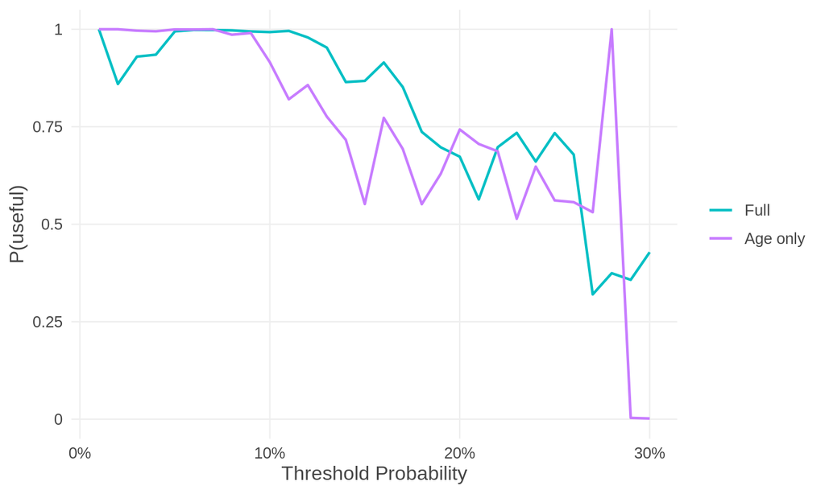

```r
plot(pu)
```

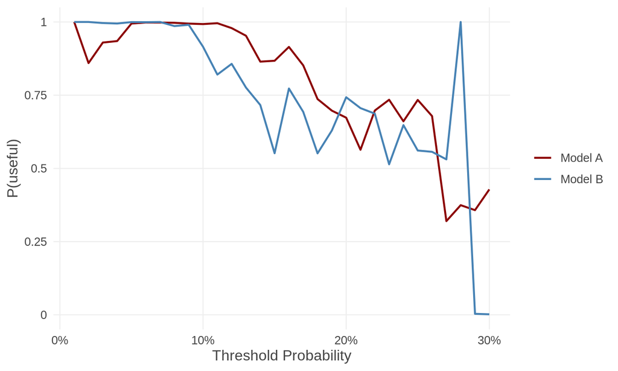

```r
plot(pu, labels = c("Model A", "Model B"), colors = c("darkred", "steelblue"))
```

**Survival** works the same way:

```r
set.seed(11)
e_surv <- evpi(res_surv, n_sim = 5000)
pu_surv <- e_surv$p_useful
print(pu_surv)
```

```
#> P(useful): Cox, Weibull; survival, horizon 5, n = 600, censoring KM, prior improper Beta(0, 0), 5000 Bayesian bootstrap draws
#>
#>  threshold   model p_useful
#>       0.05     Cox    0.000
#>       0.05 Weibull    0.000
#>       0.06     Cox    0.000
#>       0.06 Weibull    0.000
#>       0.07     Cox    0.000
#>       0.07 Weibull    0.000
#>       0.08     Cox    0.000
#>       0.08 Weibull    0.000
#>       0.09     Cox    0.000
#>       0.09 Weibull    0.000
#>       0.10     Cox    0.201
#>       0.10 Weibull    0.000
#>       0.11     Cox    0.822
#>       0.11 Weibull    0.300
#>       0.12     Cox    0.854
#>       0.12 Weibull    0.925
#>       0.13     Cox    0.983
#>       0.13 Weibull    0.581
#>       0.14     Cox    0.999
#>       0.14 Weibull    0.943
#> # 46 more thresholds; use summary() or as.data.frame()
```

```r
summary(pu_surv)
```

```
#> P(useful): Cox, Weibull; survival, horizon 5, n = 600, censoring KM, prior improper Beta(0, 0), 5000 Bayesian bootstrap draws
#> Thresholds where the probability that the model is useful is:
#>
#>    model  P > 0.95          0.5 to 0.95              P < 0.5
#>      Cox 0.13-0.47 0.11-0.12, 0.48-0.51 0.05-0.10, 0.52-0.60
#>  Weibull 0.15-0.44 0.12-0.14, 0.45-0.51 0.05-0.11, 0.52-0.60
```

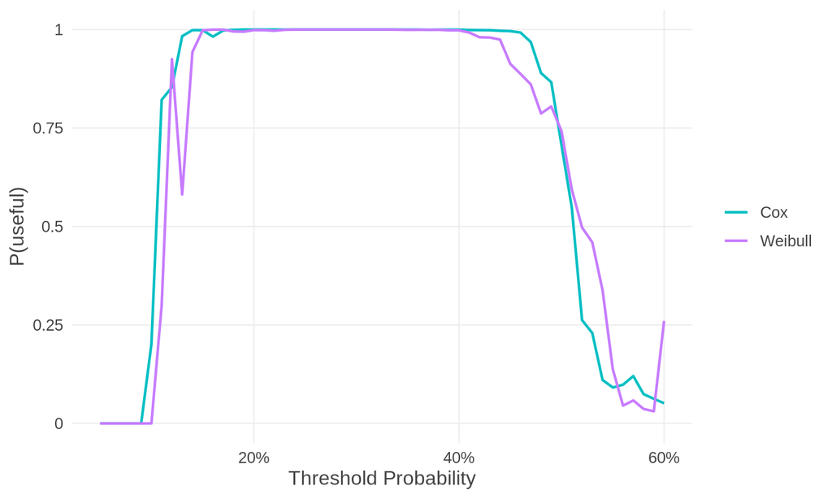

```r
plot(pu_surv)
```

## P(best)

The probability that each strategy (each model, treat all, treat none) has the highest net benefit. It compares the models with each other, so it is computed for all the models of the result together, in `e$p_best`. Ties share the draw, so the probabilities sum to 1 at each threshold.

```r
pb <- e$p_best
```

**`print()`** gives the header and, at the first thresholds, P(best) of each strategy (one row per threshold and strategy):

```r
print(pb)
```

```
#> P(best): Full, Age only; binary, n = 500, prior improper Beta(0, 0), 5000 posterior draws
#>
#>  threshold   strategy p_best
#>       0.01       Full  1.000
#>       0.01   Age only  0.000
#>       0.01  Treat All  0.000
#>       0.01 Treat None  0.000
#>       0.02       Full  0.370
#>       0.02   Age only  0.630
#>       0.02  Treat All  0.000
#>       0.02 Treat None  0.000
#>       0.03       Full  0.286
#>       0.03   Age only  0.714
#>       0.03  Treat All  0.000
#>       0.03 Treat None  0.000
#>       0.04       Full  0.250
#>       0.04   Age only  0.748
#>       0.04  Treat All  0.001
#>       0.04 Treat None  0.000
#>       0.05       Full  0.297
#>       0.05   Age only  0.703
#>       0.05  Treat All  0.000
#>       0.05 Treat None  0.000
#>       0.06       Full  0.385
#>       0.06   Age only  0.615
#>       0.06  Treat All  0.000
#>       0.06 Treat None  0.000
#>       0.07       Full  0.382
#>       0.07   Age only  0.618
#>       0.07  Treat All  0.000
#>       0.07 Treat None  0.000
#>       0.08       Full  0.581
#>       0.08   Age only  0.418
#>       0.08  Treat All  0.000
#>       0.08 Treat None  0.001
#>       0.09       Full  0.479
#>       0.09   Age only  0.519
#>       0.09  Treat All  0.000
#>       0.09 Treat None  0.002
#>       0.10       Full  0.849
#>       0.10   Age only  0.146
#>       0.10  Treat All  0.000
#>       0.10 Treat None  0.005
#> # 20 more thresholds; use summary() or as.data.frame()
```

**`summary()`** gives the strategy most likely to be the best along the thresholds, and P(best) of each strategy (all thresholds by default, or those in `thresholds`):

```r
summary(pb, thresholds = c(0.02, 0.05, 0.1, 0.2))
```

```
#> P(best): Full, Age only; binary, n = 500, prior improper Beta(0, 0), 5000 posterior draws
#> Most likely best: Full 0.01, Age only 0.02-0.07, Full 0.08, Age only 0.09, Full 0.10-0.20, Age only 0.21, Full 0.22-0.26, Age only 0.27-0.28, Full 0.29-0.30
#>
#>  threshold   strategy p_best
#>       0.02       Full  0.370
#>       0.02   Age only  0.630
#>       0.02  Treat All  0.000
#>       0.02 Treat None  0.000
#>       0.05       Full  0.297
#>       0.05   Age only  0.703
#>       0.05  Treat All  0.000
#>       0.05 Treat None  0.000
#>       0.10       Full  0.849
#>       0.10   Age only  0.146
#>       0.10  Treat All  0.000
#>       0.10 Treat None  0.005
#>       0.20       Full  0.422
#>       0.20   Age only  0.417
#>       0.20  Treat All  0.000
#>       0.20 Treat None  0.160
```

**`plot()`** draws one curve per strategy:

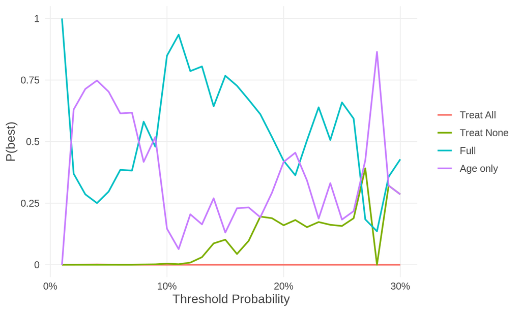

```r
plot(pb)
```

**Competing risks:**

```r
set.seed(12)
pb_cr <- evpi(res_csc, n_sim = 5000)$p_best
print(pb_cr)
```

```
#> P(best): Cause-specific Cox; competing risks (cause recurrence), horizon 5, n = 600, censoring KM, prior improper Beta(0, 0), 5000 Bayesian bootstrap draws
#>
#>  threshold           strategy p_best
#>       0.05 Cause-specific Cox  0.500
#>       0.05          Treat All  0.500
#>       0.05         Treat None  0.000
#>       0.06 Cause-specific Cox  0.500
#>       0.06          Treat All  0.500
#>       0.06         Treat None  0.000
#>       0.07 Cause-specific Cox  0.500
#>       0.07          Treat All  0.500
#>       0.07         Treat None  0.000
#>       0.08 Cause-specific Cox  0.500
#>       0.08          Treat All  0.500
#>       0.08         Treat None  0.000
#>       0.09 Cause-specific Cox  0.500
#>       0.09          Treat All  0.500
#>       0.09         Treat None  0.000
#>       0.10 Cause-specific Cox  0.500
#>       0.10          Treat All  0.500
#>       0.10         Treat None  0.000
#>       0.11 Cause-specific Cox  0.500
#>       0.11          Treat All  0.500
#>       0.11         Treat None  0.000
#>       0.12 Cause-specific Cox  0.500
#>       0.12          Treat All  0.500
#>       0.12         Treat None  0.000
#>       0.13 Cause-specific Cox  0.500
#>       0.13          Treat All  0.500
#>       0.13         Treat None  0.000
#>       0.14 Cause-specific Cox  0.500
#>       0.14          Treat All  0.500
#>       0.14         Treat None  0.000
#> # 46 more thresholds; use summary() or as.data.frame()
```

```r
summary(pb_cr, thresholds = c(0.2, 0.3, 0.4, 0.5))
```

```
#> P(best): Cause-specific Cox; competing risks (cause recurrence), horizon 5, n = 600, censoring KM, prior improper Beta(0, 0), 5000 Bayesian bootstrap draws
#> Most likely best: Cause-specific Cox 0.05-0.60
#>
#>  threshold           strategy p_best
#>        0.2 Cause-specific Cox  0.561
#>        0.2          Treat All  0.439
#>        0.2         Treat None  0.000
#>        0.3 Cause-specific Cox  0.995
#>        0.3          Treat All  0.005
#>        0.3         Treat None  0.000
#>        0.4 Cause-specific Cox  1.000
#>        0.4          Treat All  0.000
#>        0.4         Treat None  0.000
#>        0.5 Cause-specific Cox  1.000
#>        0.5          Treat All  0.000
#>        0.5         Treat None  0.000
```

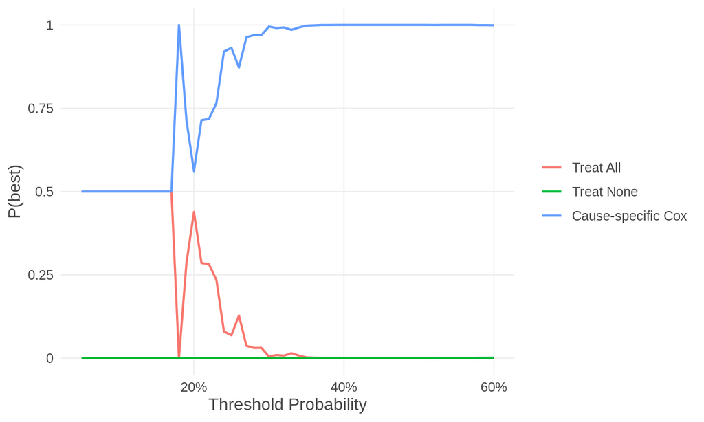

```r
plot(pb_cr)
```

## EVPI

With $ENB_{current} = \max_s E\{NB_s\}$ (use the strategy that is best on average) and $ENB_{perfect} = E\{\max_s NB_s\}$ (use the best strategy in each draw), $EVPI = ENB_{perfect} - ENB_{current} \ge 0$: the expected loss in net benefit from not knowing which strategy is best, in net true positives per patient. The relative EVPI compares the gain from perfect information with the gain from using the model(s), both over the best default strategy; 1.2 means perfect information would give 20% more net benefit than using the best model now. EVPI is the result `e` itself.

**`print()`** gives the header and EVPI and relative EVPI at the first thresholds:

```r
print(e)
```

```
#> EVPI: Full, Age only; binary, n = 500, prior improper Beta(0, 0), 5000 posterior draws
#>
#>  threshold     EVPI rEVPI
#>       0.01 0.000000 1.000
#>       0.02 0.000401 1.092
#>       0.03 0.000663 1.071
#>       0.04 0.000779 1.061
#>       0.05 0.001015 1.048
#>       0.06 0.001628 1.063
#>       0.07 0.001587 1.059
#>       0.08 0.002165 1.113
#>       0.09 0.002557 1.148
#>       0.10 0.000530 1.031
#> # 20 more rows; use summary() or as.data.frame()
#> # From the same draws: P(useful) in $p_useful, P(best) in $p_best
```

**`summary()`** gives the thresholds where EVPI is positive and its largest value, and EVPI and relative EVPI at each threshold (all thresholds by default, of which the first 10 are printed, or those in `thresholds`); P(useful) and P(best) have their own `summary()` (above):

```r
summary(e, thresholds = c(0.02, 0.05, 0.1, 0.2))
```

```
#> EVPI: Full, Age only; binary, n = 500, prior improper Beta(0, 0), 5000 posterior draws
#> EVPI > 0 at 0.02-0.30; largest 0.002557 at 0.09
#>
#>  threshold     EVPI rEVPI
#>       0.02 0.000401 1.092
#>       0.05 0.001015 1.048
#>       0.10 0.000530 1.031
#>       0.20 0.002171 1.716
```

The whole table, `as.data.frame(e)`, also has $ENB_{current}$ and $ENB_{perfect}$, and `e$ENB` the expected net benefit of each strategy.

**`plot()`** draws EVPI, or the relative EVPI, against the threshold:

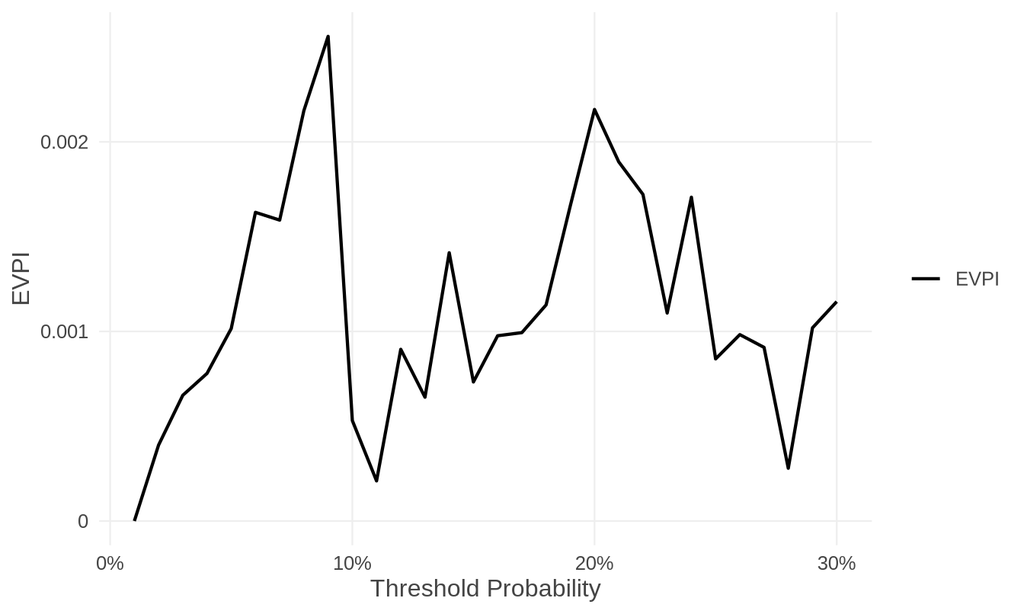

```r
plot(e)
```

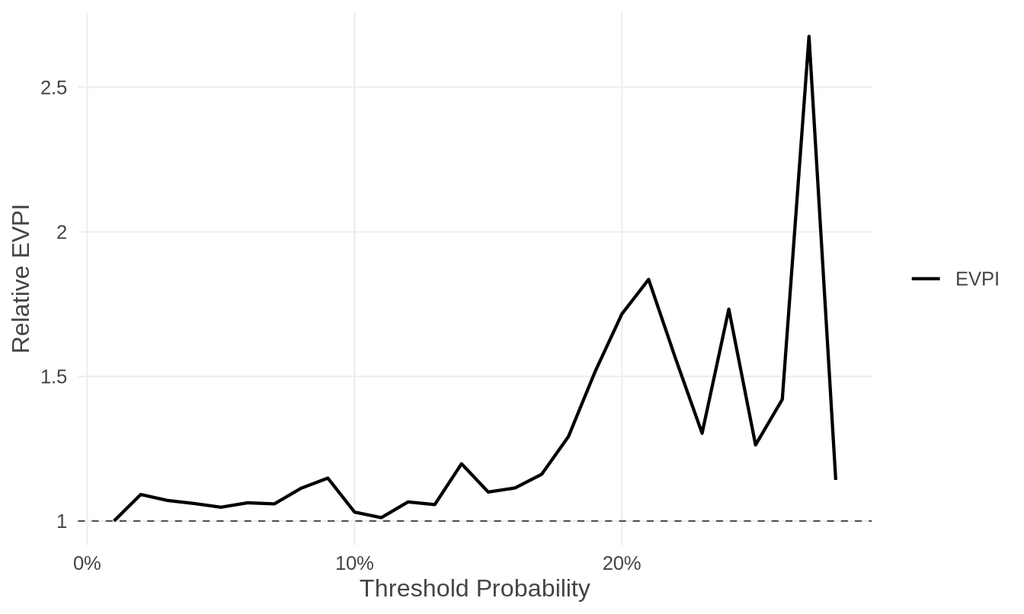

```r
plot(e, type = "relative")
```

**EVPI per 100,000 patients (`per`).** EVPI is per patient, so its values are small (0.002 is 2 net true positives per 1,000 patients). `print()`, `summary()`, `as.data.frame()` and `plot()` take `per`, the number of patients to express it per (default 1), e.g. `per = 100000` for the expected gain in net true positives per 100,000 patients with perfect information. The header and the y axis say the scale; relative EVPI, P(useful) and P(best) have no unit and do not change. The default can be set once with `options(voipred.per = 100000)`:

```r
summary(e, thresholds = c(0.02, 0.05, 0.1, 0.2), per = 100000)
```

```
#> EVPI: Full, Age only; binary, n = 500, prior improper Beta(0, 0), 5000 posterior draws, per 100,000 patients
#> EVPI > 0 at 0.02-0.30; largest 255.7 at 0.09
#>
#>  threshold  EVPI rEVPI
#>       0.02  40.1 1.092
#>       0.05 101.5 1.048
#>       0.10  53.0 1.031
#>       0.20 217.1 1.716
```

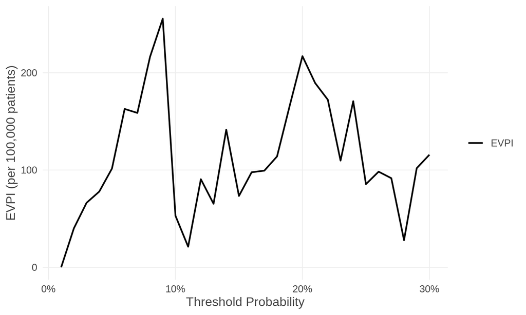

```r
plot(e, per = 100000)
```

`plot(e, type = "p_useful")` and `plot(e, type = "p_best")` draw P(useful) and P(best) from the result of `evpi()`, the same as `plot(e$p_useful)` and `plot(e$p_best)`:

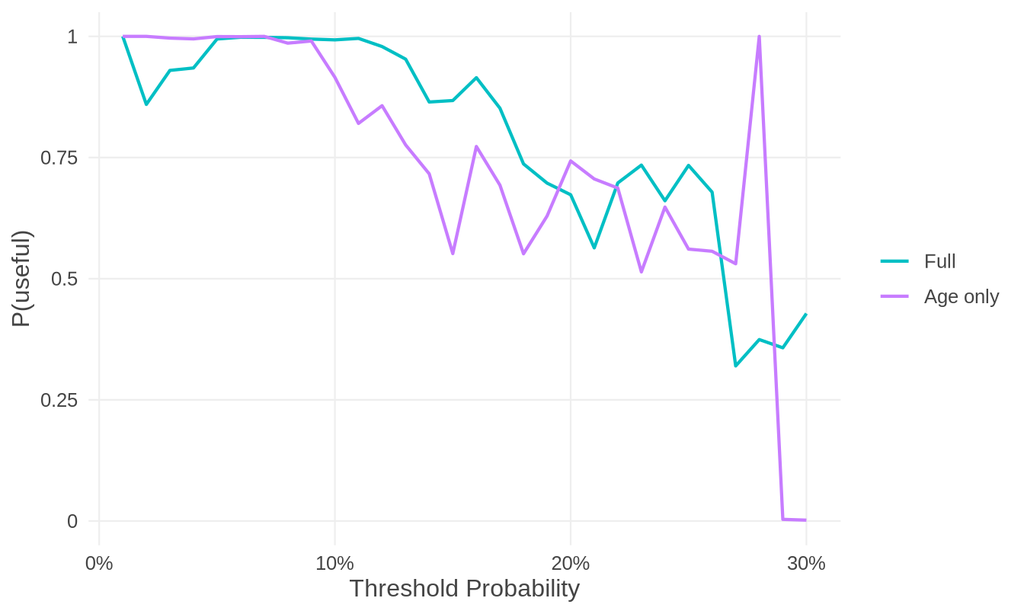

```r
plot(e, type = "p_useful")
```

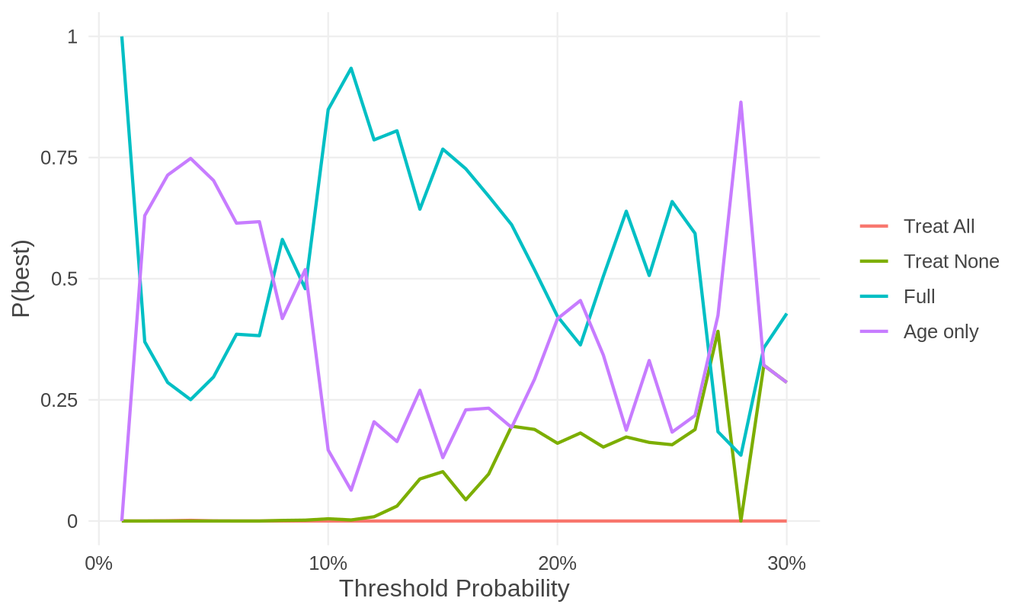

```r
plot(e, type = "p_best")
```

**Several results on one plot**, e.g. the full model alone, validated on 500 and on 2000 patients:

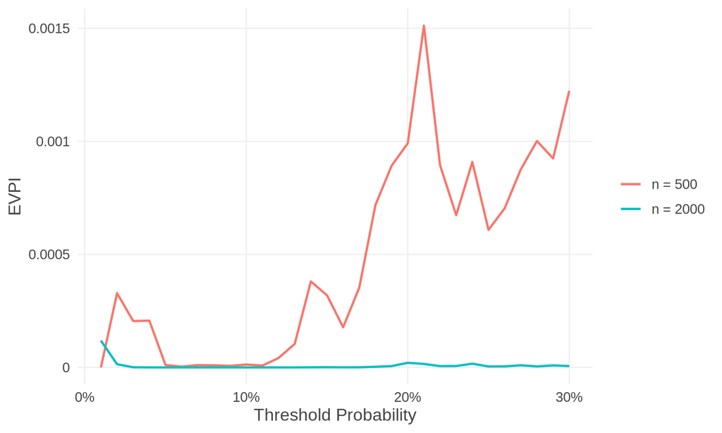

```r
res_full <- nb_val(data = df_val_binary,
                   predicted_risk = "p_full",
                   outcome = "day30",
                   thresholds = z,
                   label = "Full")
df_val_binary_2000 <- gusto[i[5001:7000], ]
df_val_binary_2000$p_full <- predict(fit_full, newdata = df_val_binary_2000,
                                     type = "response")
res_full_2000 <- nb_val(data = df_val_binary_2000,
                        predicted_risk = df_val_binary_2000$p_full,
                        outcome = "day30",
                        thresholds = z,
                        label = "Full")
set.seed(10)
e_500  <- evpi(res_full, n_sim = 5000)
e_2000 <- evpi(res_full_2000, n_sim = 5000)
plot(e_500, e_2000, labels = c("n = 500", "n = 2000"))
```

**Survival with cIPCW.** The censoring model is refitted in every draw: automatically for the Cox model of `cipcw = ~ covariates`, and for your own censoring model if it is a `coxph`, `survreg`, `rms::cph`, `rms::psm`, `flexsurvreg` or `prodlim` fit. In a draw where a few patients carry most of the weight, `coxph()` may warn that a coefficient of the censoring model may be infinite; one draw out of 5000 has a negligible effect.

```r
set.seed(41)
e_ci <- evpi(res_ci, n_sim = 5000)
```

```
#> Warning in coxph.fit(X, Y, istrat, offset, init, control, weights = weights, :
#> Loglik converged before variable 2 ; coefficient may be infinite.
```

```r
print(e_ci)
```

```
#> EVPI: Cox; survival, horizon 5, n = 600, censoring cIPCW (coxph), prior improper Beta(0, 0), 5000 Bayesian bootstrap draws
#>
#>  threshold      EVPI rEVPI
#>       0.05 0.0000000    NA
#>       0.06 0.0000000    NA
#>       0.07 0.0000000    NA
#>       0.08 0.0000000    NA
#>       0.09 0.0000000    NA
#>       0.10 0.0000613   Inf
#>       0.11 0.0003445 1.300
#>       0.12 0.0003654 1.114
#>       0.13 0.0000353 1.004
#>       0.14 0.0000002 1.000
#> # 46 more rows; use summary() or as.data.frame()
#> # From the same draws: P(useful) in $p_useful, P(best) in $p_best
```

```r
summary(e_ci, thresholds = c(0.1, 0.2, 0.3, 0.4))
```

```
#> EVPI: Cox; survival, horizon 5, n = 600, censoring cIPCW (coxph), prior improper Beta(0, 0), 5000 Bayesian bootstrap draws
#> EVPI > 0 at 0.10-0.18, 0.37-0.60; largest 0.003785 at 0.51
#>
#>  threshold       EVPI rEVPI
#>        0.1 0.00006130   Inf
#>        0.2 0.00000000 1.000
#>        0.3 0.00000000 1.000
#>        0.4 0.00000385 1.000
```

For any other censoring model of your own, give `refit_function` in `cipcw_control()` (optional, for this case only): a `function(data, weights)` that refits it with case weights. A survival tree:

```r
tree <- partykit::ctree(Surv(years, death == 0) ~ age + nodes + grade,
                        data = df_val_survival)
ctrl <- cipcw_control(
  model = tree,
  refit_function = function(data, weights)
    partykit::ctree(Surv(years, death == 0) ~ age + nodes + grade, data = data,
                    weights = weights))
res_tree <- nb_val(data = df_val_survival,
                   predicted_risk = df_val_survival$p_cox,
                   outcome = ~ Surv(years, death),
                   horizon = 5,
                   thresholds = zs,
                   cipcw = ctrl,
                   label = "Cox")
set.seed(43)
summary(evpi(res_tree, n_sim = 1000), thresholds = c(0.1, 0.2, 0.3, 0.4))
```

```
#> EVPI: Cox; survival, horizon 5, n = 600, censoring cIPCW (constparty), prior improper Beta(0, 0), 1000 Bayesian bootstrap draws
#> EVPI > 0 at 0.10-0.14, 0.16-0.18, 0.38-0.39, 0.41-0.60; largest 0.003777 at 0.51
#>
#>  threshold       EVPI rEVPI
#>        0.1 0.00005927   Inf
#>        0.2 0.00000000 1.000
#>        0.3 0.00000000 1.000
#>        0.4 0.00000000 1.000
```

**Prior information.** All the results above use the default prior, the data only. For a binary outcome, prior information can be added in `nb_val()` (e.g. `prior = nb_uniform()`, see the net benefit guide); the draws then come from that posterior. Results with different priors are not compared:

```r
u_bin <- nb_val(data = df_val_binary,
                predicted_risk = list(Full = "p_full", `Age only` = "p_age"),
                outcome = "day30",
                thresholds = z,
                prior = nb_uniform())
set.seed(30)
summary(evpi(u_bin, n_sim = 5000), thresholds = c(0.02, 0.05, 0.1, 0.2))
```

```
#> EVPI: Full, Age only; binary, n = 500, prior uniform Beta(1, 1), 5000 posterior draws
#> EVPI > 0 at 0.01-0.30; largest 0.002708 at 0.09
#>
#>  threshold     EVPI rEVPI
#>       0.02 0.000742 1.300
#>       0.05 0.001155 1.059
#>       0.10 0.000654 1.037
#>       0.20 0.002093 1.497
```

# EVSI

The expected gain in net benefit from a future validation study of $N$ patients (`future_n`), added to the current sample, before choosing the strategy, is quantified by the expected value of sample information (EVSI). It is between 0 and EVPI and approaches EVPI as $N$ grows. Two algorithms of Sadatsafavi et al. (2025) are used: the conjugate (Beta-binomial) one for a binary outcome without case weights, and the Bayesian bootstrap one otherwise (for survival, a future patient is a resampled current patient, with the same follow-up).

```r
set.seed(20)
o <- evsi(res_bin, future_n = c(250, 500, 1000, 2000, 4000), n_sim = 5000)
```

**`print()`** gives the header and, at the first thresholds, EVSI and EVPI for each future sample size (one row per threshold and size). The header states the information at the two moments that EVSI compares: **before the future study**, the prior given to `nb_val()` updated with the validation data (the same as for EVPI), and **after it**, that prior updated with the validation data and the future study together (for survival outcomes, the Bayesian bootstrap of the data, with no prior information):

```r
print(o)
```

```
#> EVSI: Full, Age only; binary, n = 500, 5000 posterior draws
#> Before the future study (as for EVPI): prior improper Beta(0, 0), updated with the validation data (n = 500)
#> Future study: 250, 500, 1,000, 2,000 or 4,000 more patients, drawn from that distribution; then the prior is updated with the validation data and the future study together
#>
#>  threshold future_n     EVSI     EVPI
#>       0.01      250 0.000000 0.000000
#>       0.01      500 0.000000 0.000000
#>       0.01    1,000 0.000000 0.000000
#>       0.01    2,000 0.000000 0.000000
#>       0.01    4,000 0.000000 0.000000
#>       0.02      250 0.000017 0.000400
#>       0.02      500 0.000146 0.000400
#>       0.02    1,000 0.000235 0.000400
#>       0.02    2,000 0.000300 0.000400
#>       0.02    4,000 0.000347 0.000400
#>       0.03      250 0.000138 0.000656
#>       0.03      500 0.000270 0.000656
#>       0.03    1,000 0.000417 0.000656
#>       0.03    2,000 0.000509 0.000656
#>       0.03    4,000 0.000574 0.000656
#>       0.04      250 0.000191 0.000819
#>       0.04      500 0.000327 0.000819
#>       0.04    1,000 0.000524 0.000819
#>       0.04    2,000 0.000640 0.000819
#>       0.04    4,000 0.000720 0.000819
#>       0.05      250 0.000253 0.001001
#>       0.05      500 0.000480 0.001001
#>       0.05    1,000 0.000642 0.001001
#>       0.05    2,000 0.000802 0.001001
#>       0.05    4,000 0.000887 0.001001
#>       0.06      250 0.000633 0.001627
#>       0.06      500 0.000911 0.001627
#>       0.06    1,000 0.001210 0.001627
#>       0.06    2,000 0.001382 0.001627
#>       0.06    4,000 0.001487 0.001627
#>       0.07      250 0.000635 0.001576
#>       0.07      500 0.000878 0.001576
#>       0.07    1,000 0.001151 0.001576
#>       0.07    2,000 0.001336 0.001576
#>       0.07    4,000 0.001422 0.001576
#>       0.08      250 0.001016 0.002177
#>       0.08      500 0.001412 0.002177
#>       0.08    1,000 0.001660 0.002177
#>       0.08    2,000 0.001891 0.002177
#>       0.08    4,000 0.002023 0.002177
#>       0.09      250 0.001372 0.002576
#>       0.09      500 0.001789 0.002576
#>       0.09    1,000 0.002077 0.002576
#>       0.09    2,000 0.002294 0.002576
#>       0.09    4,000 0.002420 0.002576
#>       0.10      250 0.000111 0.000601
#>       0.10      500 0.000191 0.000601
#>       0.10    1,000 0.000316 0.000601
#>       0.10    2,000 0.000421 0.000601
#>       0.10    4,000 0.000502 0.000601
#> # 20 more thresholds; use summary() or as.data.frame()
```

**`summary()`** gives EVSI as a percentage of EVPI, at the 3 thresholds with the largest EVPI (or at chosen `thresholds`): how much of the value of perfect information a study of each size would give:

```r
summary(o)
```

```
#> EVSI: Full, Age only; binary, n = 500, 5000 posterior draws
#> Before the future study (as for EVPI): prior improper Beta(0, 0), updated with the validation data (n = 500)
#> Future study: 250, 500, 1,000, 2,000 or 4,000 more patients, drawn from that distribution; then the prior is updated with the validation data and the future study together
#> EVSI / EVPI at the thresholds with the largest EVPI:
#>
#>  threshold future_n     EVSI     EVPI EVSI / EVPI
#>       0.08      250 0.001016 0.002177         47%
#>       0.08      500 0.001412 0.002177         65%
#>       0.08    1,000 0.001660 0.002177         76%
#>       0.08    2,000 0.001891 0.002177         87%
#>       0.08    4,000 0.002023 0.002177         93%
#>       0.09      250 0.001372 0.002576         53%
#>       0.09      500 0.001789 0.002576         69%
#>       0.09    1,000 0.002077 0.002576         81%
#>       0.09    2,000 0.002294 0.002576         89%
#>       0.09    4,000 0.002420 0.002576         94%
#>       0.20      250 0.001080 0.002188         49%
#>       0.20      500 0.001429 0.002188         65%
#>       0.20    1,000 0.001720 0.002188         79%
#>       0.20    2,000 0.001943 0.002188         89%
#>       0.20    4,000 0.002036 0.002188         93%
```

```r
summary(o, thresholds = c(0.05, 0.1, 0.2))
```

```
#> EVSI: Full, Age only; binary, n = 500, 5000 posterior draws
#> Before the future study (as for EVPI): prior improper Beta(0, 0), updated with the validation data (n = 500)
#> Future study: 250, 500, 1,000, 2,000 or 4,000 more patients, drawn from that distribution; then the prior is updated with the validation data and the future study together
#> EVSI / EVPI at the chosen thresholds:
#>
#>  threshold future_n     EVSI     EVPI EVSI / EVPI
#>       0.05      250 0.000253 0.001001         25%
#>       0.05      500 0.000480 0.001001         48%
#>       0.05    1,000 0.000642 0.001001         64%
#>       0.05    2,000 0.000802 0.001001         80%
#>       0.05    4,000 0.000887 0.001001         89%
#>       0.10      250 0.000111 0.000601         18%
#>       0.10      500 0.000191 0.000601         32%
#>       0.10    1,000 0.000316 0.000601         53%
#>       0.10    2,000 0.000421 0.000601         70%
#>       0.10    4,000 0.000502 0.000601         84%
#>       0.20      250 0.001080 0.002188         49%
#>       0.20      500 0.001429 0.002188         65%
#>       0.20    1,000 0.001720 0.002188         79%
#>       0.20    2,000 0.001943 0.002188         89%
#>       0.20    4,000 0.002036 0.002188         93%
```

**`plot()`** draws EVSI against the future sample size, one curve per threshold (all thresholds if there are at most 5, otherwise the 4 with the largest EVPI, or those in `thresholds`), with EVPI as a dashed line:

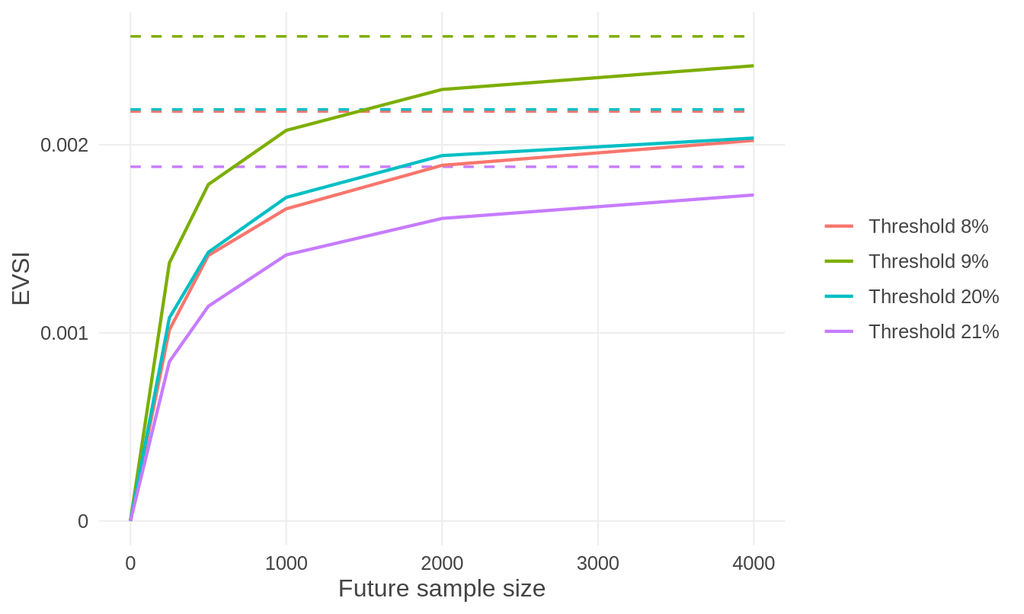

```r
plot(o)
```

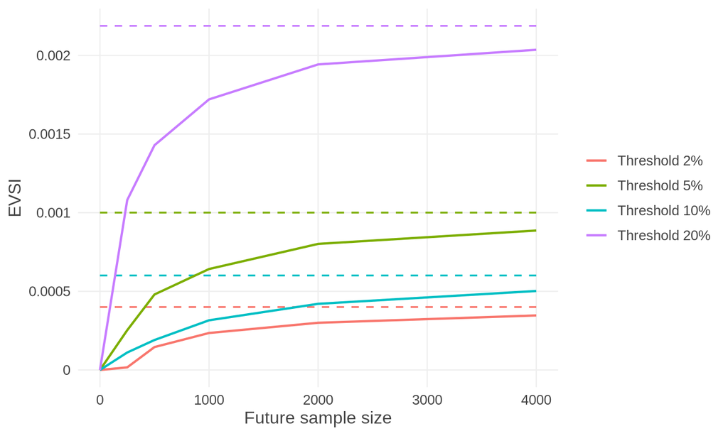

```r
plot(o, thresholds = c(0.02, 0.05, 0.1, 0.2))
```

EVSI, like EVPI, can be expressed per more patients with `per` (in `print()`, `summary()`, `as.data.frame()` and `plot()`):

```r
summary(o, thresholds = c(0.05, 0.1), per = 100000)
```

```
#> EVSI: Full, Age only; binary, n = 500, 5000 posterior draws, per 100,000 patients
#> Before the future study (as for EVPI): prior improper Beta(0, 0), updated with the validation data (n = 500)
#> Future study: 250, 500, 1,000, 2,000 or 4,000 more patients, drawn from that distribution; then the prior is updated with the validation data and the future study together
#> EVSI / EVPI at the chosen thresholds:
#>
#>  threshold future_n  EVSI  EVPI EVSI / EVPI
#>       0.05      250 25.28 100.1         25%
#>       0.05      500 48.01 100.1         48%
#>       0.05    1,000 64.19 100.1         64%
#>       0.05    2,000 80.16 100.1         80%
#>       0.05    4,000 88.67 100.1         89%
#>       0.10      250 11.10  60.1         18%
#>       0.10      500 19.05  60.1         32%
#>       0.10    1,000 31.59  60.1         53%
#>       0.10    2,000 42.06  60.1         70%
#>       0.10    4,000 50.23  60.1         84%
```

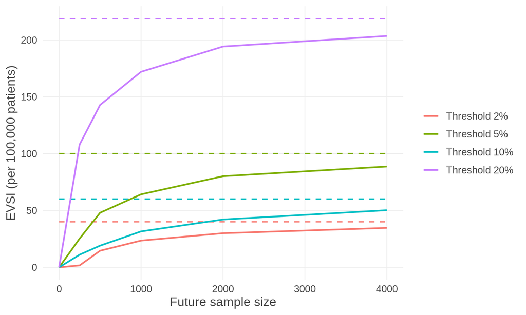

```r
plot(o, thresholds = c(0.02, 0.05, 0.1, 0.2), per = 100000)
```

Small negative values of EVSI where EVPI is close to 0 are Monte Carlo error: EVSI is about 0 there.

**Survival:**

```r
set.seed(41)
o_s <- evsi(res_surv, future_n = c(500, 1000, 2000, 4000), n_sim = 5000)
print(o_s)
```

```
#> EVSI: Cox, Weibull; survival, horizon 5, n = 600, censoring KM, 5000 Bayesian bootstrap draws
#> Before the future study (as for EVPI): the validation data (n = 600), Bayesian bootstrap (prior improper Beta(0, 0): the data only)
#> Future study: 500, 1,000, 2,000 or 4,000 more patients, resampled from each draw; then the validation data and the future study together
#>
#>  threshold future_n       EVSI      EVPI
#>       0.05      500  0.0000000 0.0000000
#>       0.05    1,000  0.0000000 0.0000000
#>       0.05    2,000  0.0000000 0.0000000
#>       0.05    4,000  0.0000000 0.0000000
#>       0.06      500  0.0000000 0.0000000
#>       0.06    1,000  0.0000000 0.0000000
#>       0.06    2,000  0.0000000 0.0000000
#>       0.06    4,000  0.0000000 0.0000000
#>       0.07      500  0.0000000 0.0000000
#>       0.07    1,000  0.0000000 0.0000000
#>       0.07    2,000  0.0000000 0.0000000
#>       0.07    4,000  0.0000000 0.0000000
#>       0.08      500  0.0000000 0.0000000
#>       0.08    1,000  0.0000000 0.0000000
#>       0.08    2,000  0.0000000 0.0000000
#>       0.08    4,000  0.0000000 0.0000000
#>       0.09      500  0.0000000 0.0000000
#>       0.09    1,000  0.0000000 0.0000000
#>       0.09    2,000  0.0000000 0.0000000
#>       0.09    4,000  0.0000000 0.0000000
#>       0.10      500 -0.0000007 0.0000574
#>       0.10    1,000  0.0000109 0.0000574
#>       0.10    2,000  0.0000227 0.0000574
#>       0.10    4,000  0.0000381 0.0000574
#>       0.11      500  0.0001616 0.0003376
#>       0.11    1,000  0.0002225 0.0003376
#>       0.11    2,000  0.0002659 0.0003376
#>       0.11    4,000  0.0002983 0.0003376
#>       0.12      500  0.0005700 0.0009665
#>       0.12    1,000  0.0007011 0.0009665
#>       0.12    2,000  0.0008066 0.0009665
#>       0.12    4,000  0.0008767 0.0009665
#>       0.13      500  0.0000139 0.0001407
#>       0.13    1,000  0.0000501 0.0001407
#>       0.13    2,000  0.0000659 0.0001407
#>       0.13    4,000  0.0001048 0.0001407
#>       0.14      500  0.0000358 0.0002625
#>       0.14    1,000  0.0000970 0.0002625
#>       0.14    2,000  0.0001505 0.0002625
#>       0.14    4,000  0.0002050 0.0002625
#> # 46 more thresholds; use summary() or as.data.frame()
```

```r
summary(o_s)
```

```
#> EVSI: Cox, Weibull; survival, horizon 5, n = 600, censoring KM, 5000 Bayesian bootstrap draws
#> Before the future study (as for EVPI): the validation data (n = 600), Bayesian bootstrap (prior improper Beta(0, 0): the data only)
#> Future study: 500, 1,000, 2,000 or 4,000 more patients, resampled from each draw; then the validation data and the future study together
#> EVSI / EVPI at the thresholds with the largest EVPI:
#>
#>  threshold future_n     EVSI     EVPI EVSI / EVPI
#>       0.50      500 0.002330 0.003992         58%
#>       0.50    1,000 0.002915 0.003992         73%
#>       0.50    2,000 0.003313 0.003992         83%
#>       0.50    4,000 0.003634 0.003992         91%
#>       0.51      500 0.003044 0.004897         62%
#>       0.51    1,000 0.003721 0.004897         76%
#>       0.51    2,000 0.004138 0.004897         84%
#>       0.51    4,000 0.004494 0.004897         92%
#>       0.52      500 0.002500 0.004036         62%
#>       0.52    1,000 0.002994 0.004036         74%
#>       0.52    2,000 0.003448 0.004036         85%
#>       0.52    4,000 0.003690 0.004036         91%
```

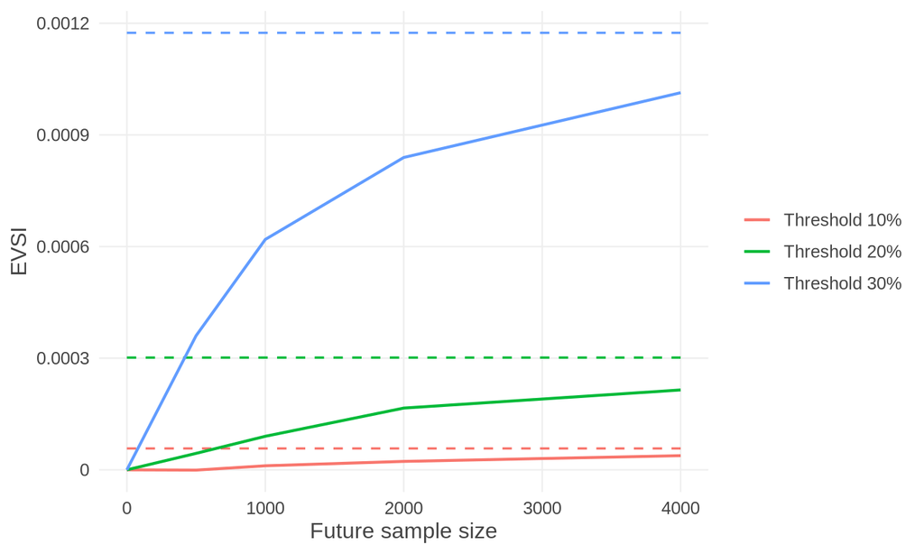

```r
plot(o_s, thresholds = c(0.1, 0.2, 0.3))
```

# Using the results as data frames

Every result is a list, and `as.data.frame()` gives its whole table (the same as `$estimates`), with fixed column names and one row per threshold (and per model, strategy or future sample size):

| Data frame | Columns |
| --- | --- |
| `as.data.frame(e)` | `threshold`, `ENB_current`, `ENB_perfect`, `EVPI`, `rEVPI` |
| `as.data.frame(e$p_useful)` | `threshold`, `model`, `p_useful` |
| `as.data.frame(e$p_best)` | `threshold`, `strategy`, `p_best` |
| `as.data.frame(o)` (EVSI) | `threshold`, `future_n`, `EVSI`, `EVPI` |
| `as.data.frame(res_bin)` (net benefit) | `threshold`, `model`, `NB_model`, `NB_all`, `NB_none`, `delta_NB` |

```r
d_evpi <- as.data.frame(e)
d_useful <- as.data.frame(e$p_useful)
d_best <- as.data.frame(e$p_best)
head(d_evpi, 3)
```

```
#>   threshold ENB_current ENB_perfect         EVPI    rEVPI
#> 1      0.01  0.05821260  0.05821260 0.0000000000 1.000000
#> 2      0.02  0.05139915  0.05179976 0.0004006056 1.091728
#> 3      0.03  0.04653742  0.04720075 0.0006633296 1.071096
```

```r
head(d_useful, 4)
```

```
#>   threshold model p_useful
#> 1      0.01  Full   1.0000
#> 2      0.02  Full   0.8596
#> 3      0.03  Full   0.9298
#> 4      0.04  Full   0.9348
```

```r
head(d_best, 4)
```

```
#>   threshold strategy p_best
#> 1      0.01     Full 1.0000
#> 2      0.02     Full 0.3698
#> 3      0.03     Full 0.2858
#> 4      0.04     Full 0.2504
```

With `per`, `as.data.frame()` keeps these columns and adds the scaled net benefit, EVPI or EVSI, named `<column>_per_<per>` (probabilities are not scaled):

```r
head(as.data.frame(e, per = 100000), 3)
```

```
#>   threshold ENB_current ENB_perfect         EVPI    rEVPI
#> 1      0.01  0.05821260  0.05821260 0.0000000000 1.000000
#> 2      0.02  0.05139915  0.05179976 0.0004006056 1.091728
#> 3      0.03  0.04653742  0.04720075 0.0006633296 1.071096
#>   ENB_current_per_100000 ENB_perfect_per_100000 EVPI_per_100000
#> 1               5821.260               5821.260         0.00000
#> 2               5139.915               5179.976        40.06056
#> 3               4653.742               4720.075        66.33296
```

```r
head(as.data.frame(o, per = 100000), 3)
```

```
#>   threshold future_n         EVSI         EVPI EVSI_per_100000 EVPI_per_100000
#> 1      0.01      250 0.0000000000 0.0000000000         0.00000         0.00000
#> 2      0.02      250 0.0000165917 0.0004001524         1.65917        40.01524
#> 3      0.03      250 0.0001375864 0.0006557044        13.75864        65.57044
```

```r
d_useful[round(d_useful$threshold, 2) == 0.1, ]                 # P(useful) at 0.1
```

```
#>    threshold    model p_useful
#> 10       0.1     Full   0.9928
#> 40       0.1 Age only   0.9154
```

```r
d_best[round(d_best$threshold, 2) == 0.1, ]                     # P(best) at 0.1
```

```
#>     threshold   strategy p_best
#> 10        0.1       Full 0.8490
#> 40        0.1   Age only 0.1464
#> 70        0.1  Treat All 0.0000
#> 100       0.1 Treat None 0.0046
```

```r
d_evpi$EVPI[round(d_evpi$threshold, 2) == 0.1]                  # EVPI at 0.1
```

```
#> [1] 0.00053006
```

```r
d_evsi <- as.data.frame(o)
d_evsi[round(d_evsi$threshold, 2) == 0.1 & d_evsi$future_n == 2000, ]  # EVSI at 0.1, N = 2000
```

```
#>     threshold future_n        EVSI         EVPI
#> 100       0.1     2000 0.000420564 0.0006005757
```

**Combining them.** As the tables share the column `threshold` (and `model`), they can be merged into one, e.g. the net benefit, P(useful) and P(best) of each model, with EVPI, at each threshold:

```r
d_nb <- as.data.frame(res_bin)
d_models <- merge(d_nb[, c("threshold", "model", "NB_model", "delta_NB")], d_useful,
                  by = c("threshold", "model"))
d_models <- merge(d_models, d_best, by.x = c("threshold", "model"),
                  by.y = c("threshold", "strategy"))
d_models <- merge(d_models, d_evpi[, c("threshold", "EVPI")], by = "threshold")
# by threshold, then the models in their order in the result
d_models <- d_models[order(d_models$threshold, match(d_models$model, res_bin$models)), ]
d_models[round(d_models$threshold, 2) %in% c(0.02, 0.05, 0.1), ]
```

```
#>    threshold    model   NB_model    delta_NB p_useful p_best         EVPI
#> 4       0.02     Full 0.04987755 0.002938776   0.8596 0.3698 0.0004006056
#> 3       0.02 Age only 0.05130612 0.004367347   1.0000 0.6302 0.0004006056
#> 10      0.05     Full 0.03484211 0.018000000   0.9946 0.2972 0.0010152118
#> 9       0.05 Age only 0.03821053 0.021368421   0.9996 0.7026 0.0010152118
#> 20      0.10     Full 0.01711111 0.017111111   0.9928 0.8490 0.0005300600
#> 19      0.10 Age only 0.01000000 0.010000000   0.9154 0.1464 0.0005300600
```

**Reshaping.** One column per strategy (e.g. for a report table) with `reshape()`:

```r
d_best_wide <- reshape(d_best, idvar = "threshold", timevar = "strategy",
                       direction = "wide")
head(d_best_wide, 3)
```

```
#>   threshold p_best.Full p_best.Age only p_best.Treat All p_best.Treat None
#> 1      0.01      1.0000          0.0000            0e+00                 0
#> 2      0.02      0.3698          0.6302            0e+00                 0
#> 3      0.03      0.2858          0.7138            4e-04                 0
```

The data frames can also be saved (e.g. `write.csv(d_models, "voi.csv", row.names = FALSE)`) or drawn in your own way, e.g. with ggplot2:

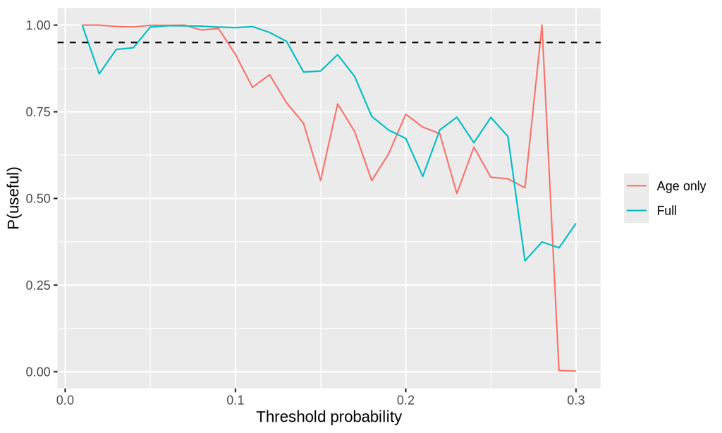

```r
library(ggplot2)
ggplot(d_useful, aes(threshold, p_useful, colour = model)) +
  geom_line() +
  geom_hline(yintercept = 0.95, linetype = "dashed") +
  labs(x = "Threshold probability", y = "P(useful)", colour = NULL)
```

# EVPI and EVSI below the decision curve

`plot()` of `nb_val()` results draws EVPI and EVSI in a panel below the decision curve, on the same threshold axis (without `evpi`, the panel takes the EVPI of the `evsi()` result):

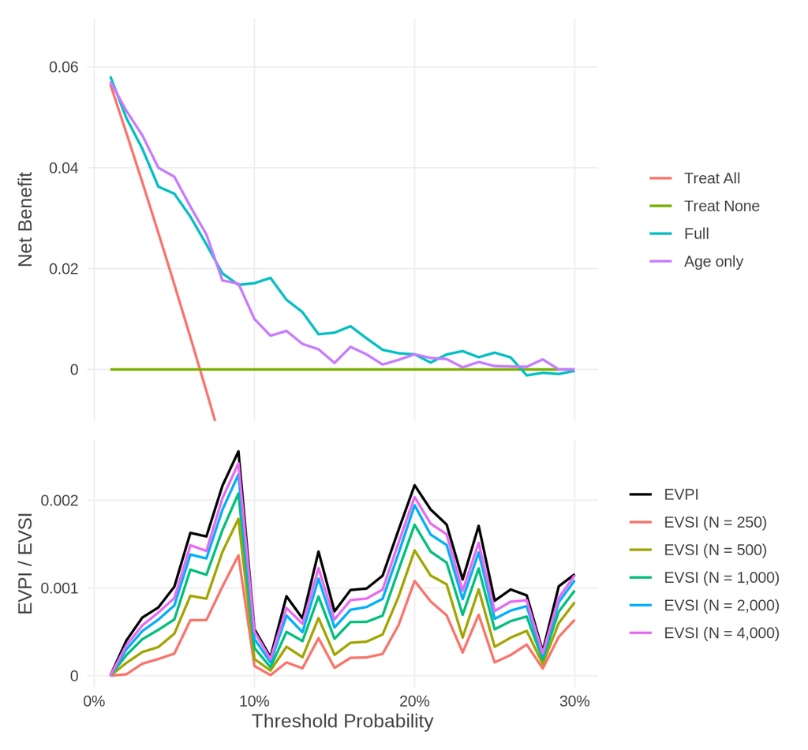

```r
plot(res_bin, evpi = e, evsi = o)
```

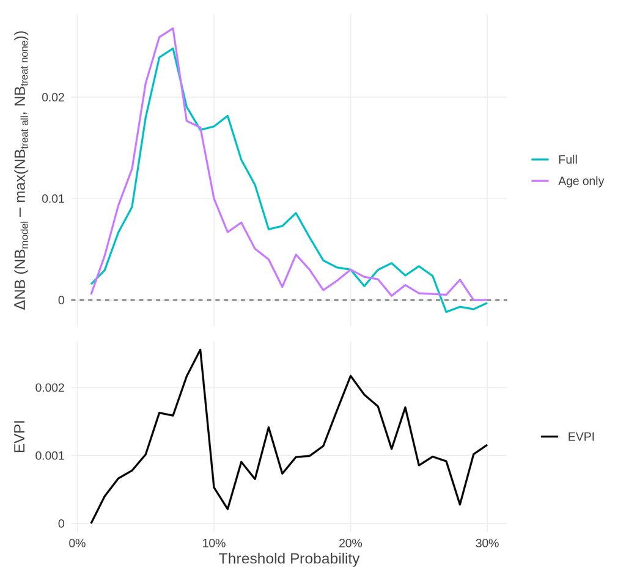

```r
plot(res_bin, type = "delta", evpi = e)
```

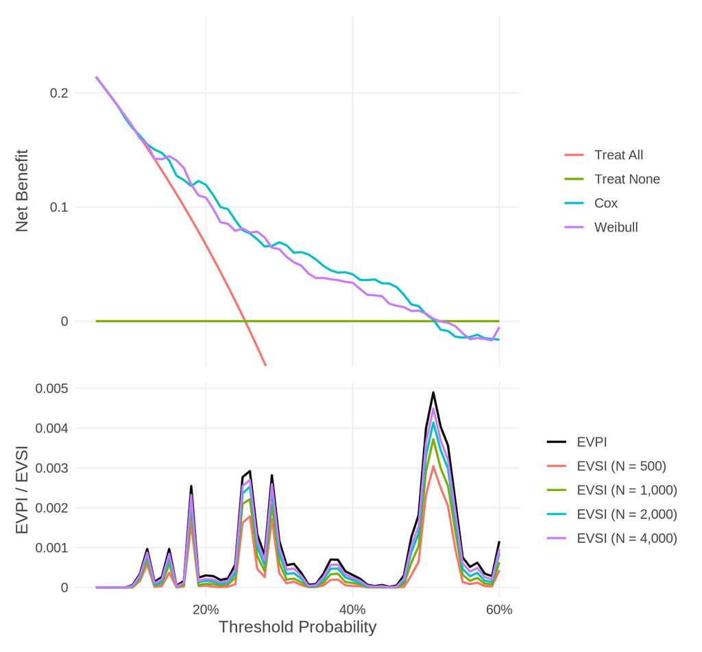

```r
plot(res_surv, evsi = o_s)
```

With `per`, both panels are on the same scale, and both y axes say it:

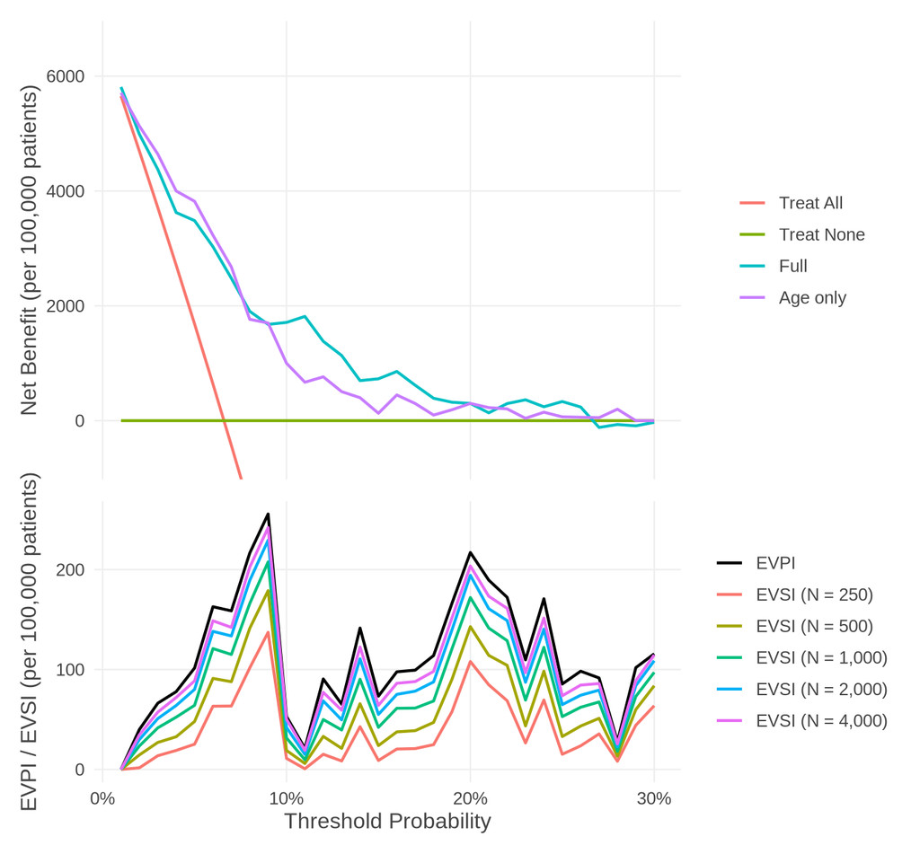

```r
plot(res_bin, evpi = e, evsi = o, per = 100000)
```

# Interactive plots

Every plot takes `interactive = TRUE` for a plotly version: hovering shows the values of all the curves, and clicking a legend entry hides a curve.

```r
plot(pu, interactive = TRUE)
```

[interactive chart not shown]

```r
plot(o, thresholds = c(0.02, 0.05, 0.1, 0.2), interactive = TRUE)
```

[interactive chart not shown]

```r
plot(res_bin, evpi = e, evsi = o, interactive = TRUE)
```

[interactive chart not shown]

# Checks

```r
evpi(res_bin, n_sim = 1)                      # at least 2 draws
```

```
#> Error:
#> ! `n_sim` must be a whole number of at least 2.
```

```r
evpi(res_bin, res_surv)                       # results that cannot be compared
```

```
#> Error:
#> ! "Full, Age only" and "Cox, Weibull" cannot be used together: different outcome type, horizon, cause, censoring method, number of patients, thresholds. Compute them with nb_val() on the same data, outcome, horizon, cause, censoring, prior and thresholds, or together in one call of nb_val().
```

```r
evpi(res_bin, u_bin,                          # different priors
     labels = c("Full", "Age", "Full (uniform)", "Age (uniform)"))
```

```
#> Error:
#> ! "Full, Age" and "Full (uniform), Age (uniform)" cannot be used together: different prior. Compute them with nb_val() on the same data, outcome, horizon, cause, censoring, prior and thresholds, or together in one call of nb_val().
```

```r
evpi(as.data.frame(res_bin))                  # not a result of nb_val()
```

```
#> Error:
#> ! evpi() needs results of nb_val().
```

```r
evsi(res_bin)                                 # future_n is required
```

```
#> Error:
#> ! `future_n` must be one or more positive whole numbers: the sizes of the future validation sample.
```

```r
plot(o, thresholds = 0.055)                   # not a threshold of the result
```

```
#> Error:
#> ! Threshold 0.055 is not among the thresholds of the result.
```

```r
evpi(res_bin, labels = "a")                   # one label per model
```

```
#> Error:
#> ! `labels` must be 2 strings, one per model.
```

```r
plot(res_bin, evpi = pu)                      # evpi = must be a result of evpi()
```

```
#> Error:
#> ! `evpi` must be a result of evpi().
```

```r
plot(res_bin, colors = c(Nope = "red"))       # colours named by label
```

```
#> Error:
#> ! `colors` names "Nope", which is not a curve of this plot: "Treat All", "Treat None", "Full", "Age only".
```

# Results computed separately

The models in this guide were given to one call of `nb_val()`. Results computed separately, for example by different people or at different times, can be given to the VoI functions together, as long as they come from the same data, outcome, thresholds and prior (and horizon and censoring): `evpi(res_a, res_b)` (with its P(useful) and P(best)) and `evsi(res_a, res_b, future_n = ...)`. They are combined (as by `c()`), and the results are the same as with one call:

```r
res_full_only <- nb_val(data = df_val_binary, predicted_risk = "p_full",
                        outcome = "day30", thresholds = z, label = "Full")
res_age_only <- nb_val(data = df_val_binary, predicted_risk = "p_age",
                       outcome = "day30", thresholds = z, label = "Age only")
set.seed(50)
e_separate <- evpi(res_full_only, res_age_only)
set.seed(50)
e_one_call <- evpi(res_bin)
all.equal(e_separate$estimates, e_one_call$estimates)
```

```
#> [1] TRUE
```

```r
all.equal(e_separate$p_best$estimates, e_one_call$p_best$estimates)
```

```
#> [1] TRUE
```

# References

- Sadatsafavi M, Lee TY, Wynants L, Vickers AJ, Gustafson P. Value-of-information analysis for external validation of risk prediction models. *Medical Decision Making* 2023; 43(5): 564-575.
- Sadatsafavi M, et al. Expected value of sample information calculations for risk prediction model validation. *Medical Decision Making* 2025; 45(3): 232-244.
- Rubin DB. The Bayesian bootstrap. *Annals of Statistics* 1981; 9(1): 130-134.
- Cruz GNF, Korthauer K. Bayesian decision curve analysis with bayesDCA. *Statistics in Medicine* 2025.
- The GUSTO investigators. An international randomized trial comparing four thrombolytic strategies for acute myocardial infarction. *New England Journal of Medicine* 1993; 329: 673-682.
- Royston P, Altman DG. External validation of a Cox prognostic model: principles and methods. *BMC Medical Research Methodology* 2013; 13: 33.
- Wynants L, Riley RD, Timmerman D, Van Calster B. Random-effects meta-analysis of the clinical utility of tests and prediction models. *Statistics in Medicine* 2018; 37: 2034-2052.